# Prob1

## Avaliação das Series pela IMDB

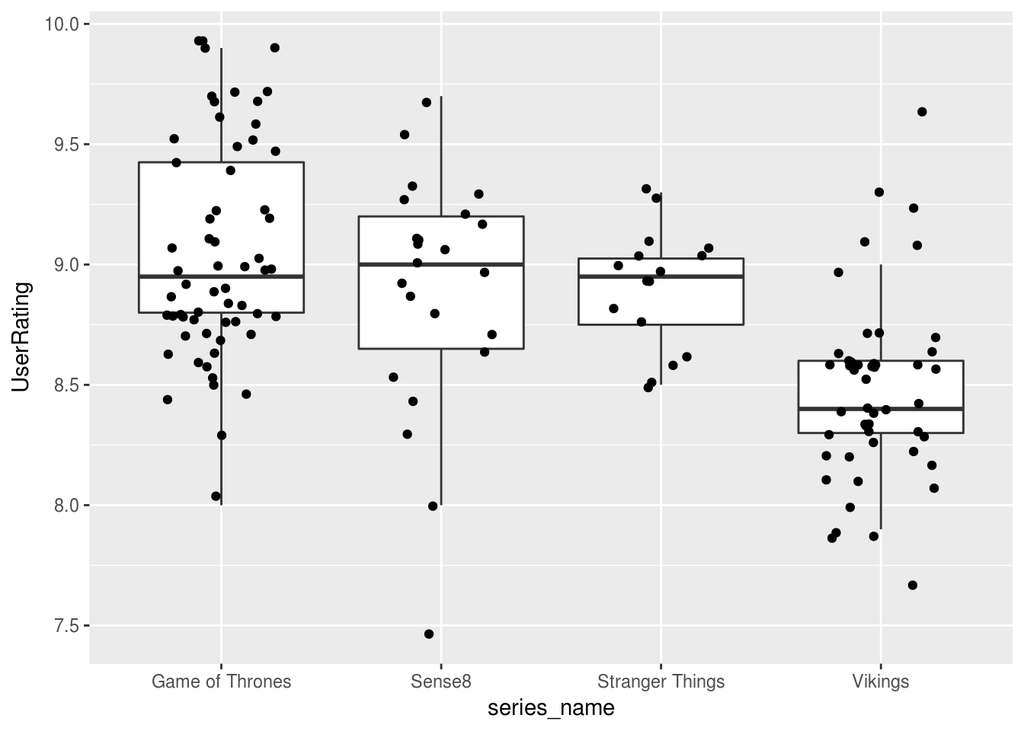

## Sense8

Se observarmos o gráfico abaixo podemos notar que há irregularidades na qualidade dos epsódios durante cada temporada, mas temos que o primeiro epsodio de cada temporada têm uma avaliação mais baixa do que o ultimo epsodio da mesma temporada. Será que isso ocorre nas outras series?

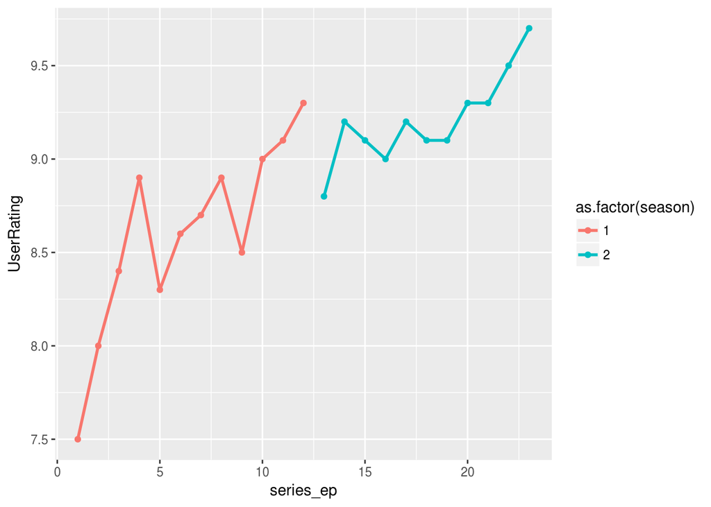

Podemos observar por esse outro gráfico que qualidade dos epsódios apesar de variarem se concentram, para essa série, entre 9.0 e 9.25 e podemos notar tambêm pela correlação de kendall, nos valores abaixo do grafico que representão o quão ordenada as avaliações estão(quanto mais o valor estiver proximo de 1 mais ordenados estão as avaliações dos epsódios), que a série não parece variar tanto a sua qualidade.

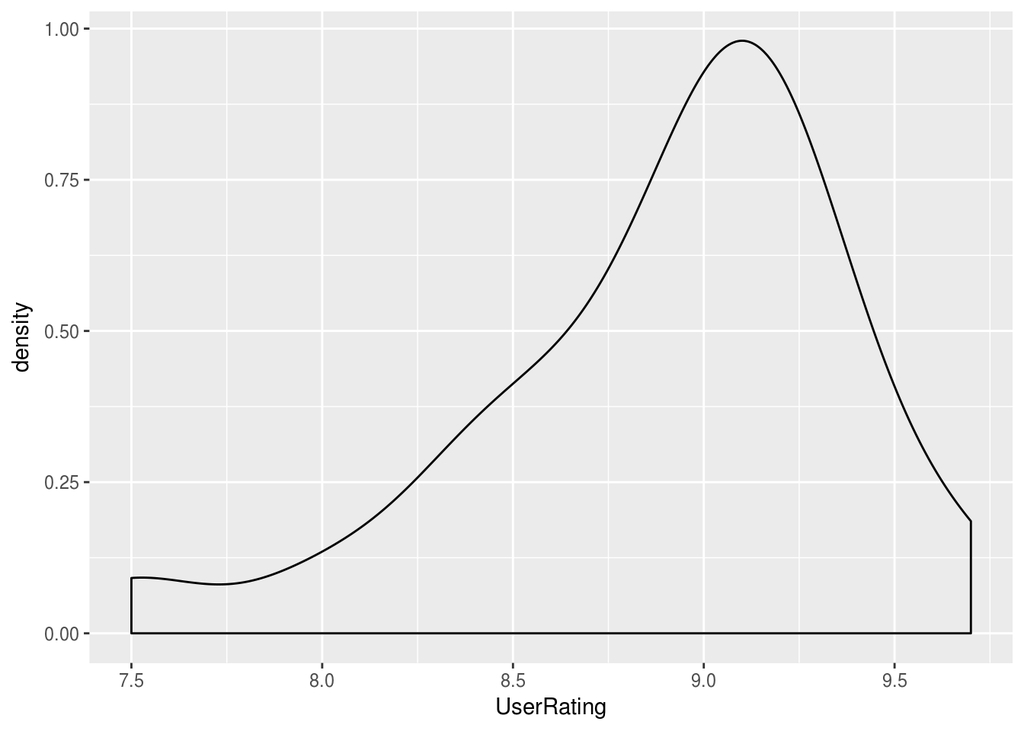

```
## # A tibble: 2 x 2
##   season correlacao_kendall
##    <int>              <dbl>
## 1      1          0.7481134
## 2      2          0.6864931
```

## Stranger Things

Observando o gráfico abaixo notamos o mesmo padrão do grafico 1 de Sense8, que o primeiro epsódio possuem qualidade menor que o último epsódio, mas parece que suas variações não são de grande magnitude.

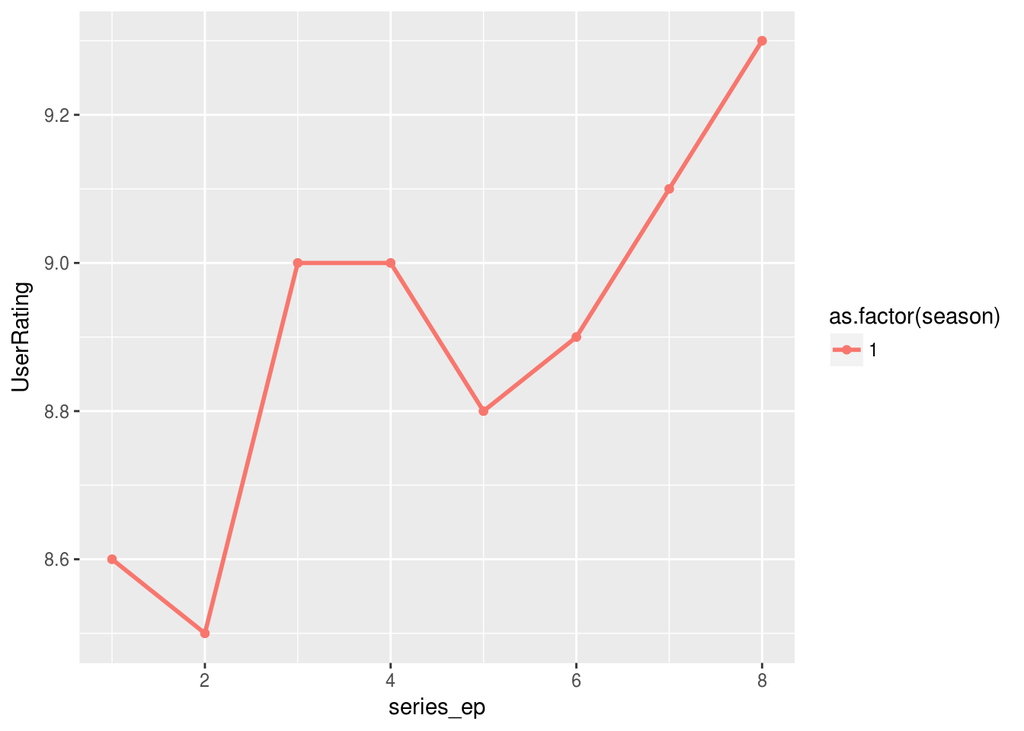

Nesse segundo gráfico de Stranger Things podemos notar que há uma certa concentração de avaliações proximo a 9.0 porém, temos uma segunda concentração, como podemos ver pelo segundo topo no gráfico, que nos indicam que os epsódios não possuem uma avaliação tão regular quanto a série anterior. Também notamos, pela correlação de kendall, que a qualidade da série varia mais que Sense8, mas a diferença não nos parece ser grande se compararmmos a segunda temporadade sense8 os valores serão distintos apenas apartir da segunda casa após a virgula.

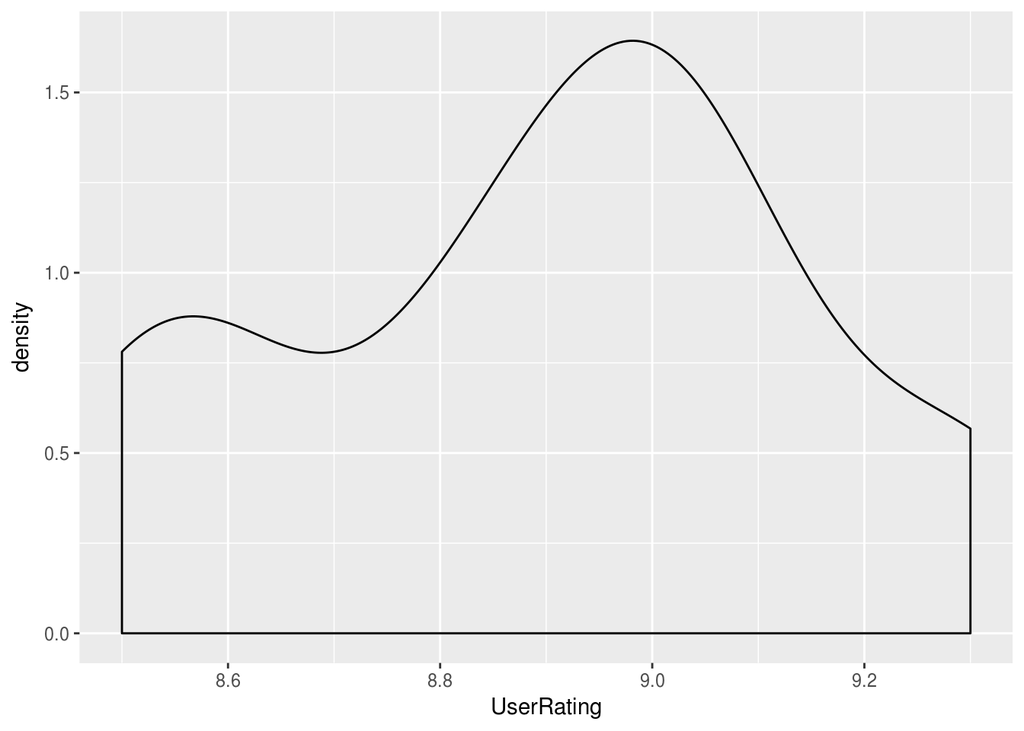

```
## # A tibble: 1 x 2
##   season correlacao_kendall
##    <int>              <dbl>
## 1      1           0.618284
```

## Game of Thrones

Aqui tambêm observamos que o primeiro epsódio de cada temporada tem sempre uma avaliação inferior ao ultimo, porém notamos aparentemente uma maior oscilação na qualidade dos epsódios do que nas séies anteriores.

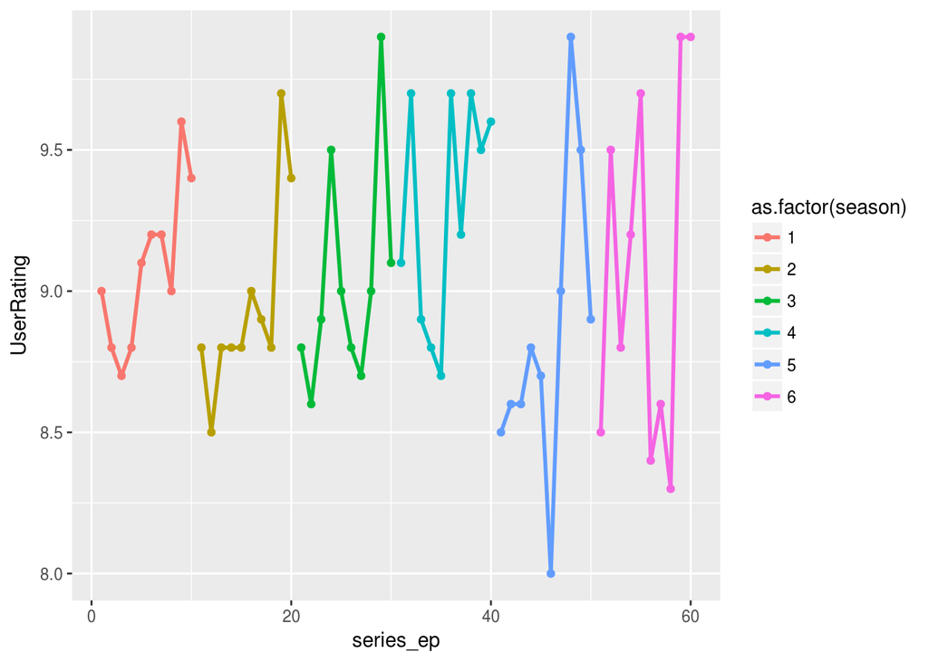

Como em Stanger Things notamos dois picos de concentrações avaliações o que nos leva a acreditar que a série é tem epsodios com avaliações tao irregulares quanto Stranger Things. Notamos ainda que, pelo valor da correlação de kendall, algumas temporadas são mais irregulares do que as outras, como por exemplo a 4ª e a 6ª temporadas, que se observarmos pelo grafico 1 dessa série é notavél essa variação.

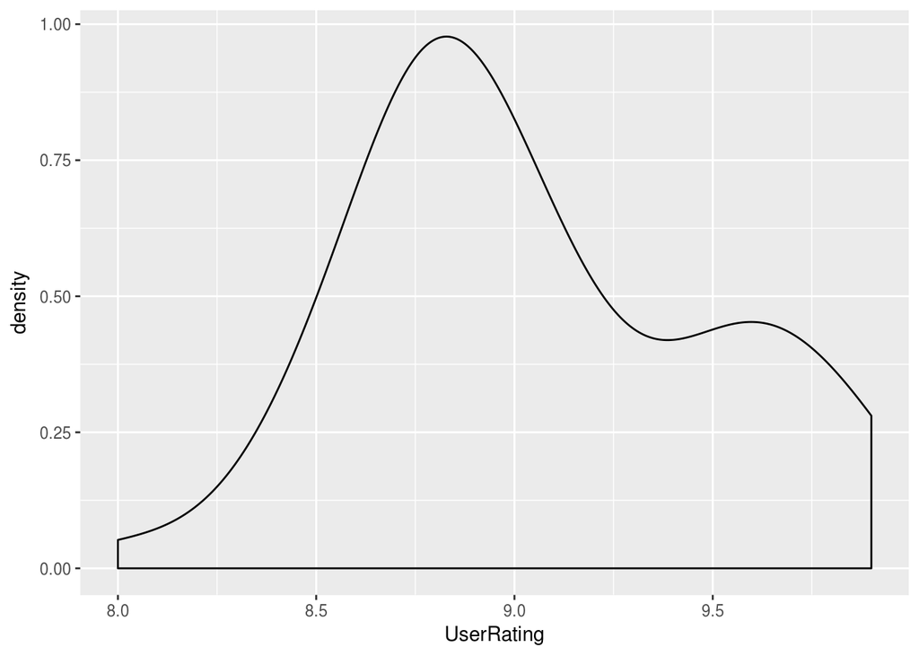

```
## # A tibble: 6 x 2
##   season correlacao_kendall
##    <int>              <dbl>
## 1      1          0.5980568
## 2      2          0.6299408
## 3      3          0.3864635
## 4      4          0.1840175
## 5      5          0.5393599
## 6      6          0.1797866
```

## Vikings

Ao observarmos esse ultimo podemos perceber que existe um padrão nas avaliações e que apesar de haver oscilações nas notas avaliativas, temos que para essas quatro séries seus ultimos epsódios são sempre melhores avaliados do que os primeiros de cada temporada, também notamos que as oscilações na qualidade dos epsódios são parecidas com as de Game of Thrones.

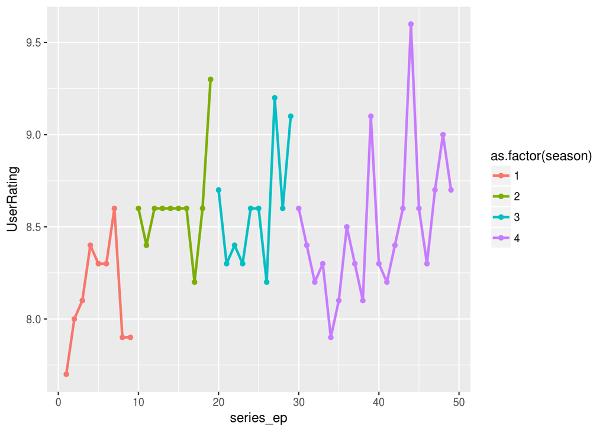

Bem aqui já nos deparamos com uma condição um “pouco” diferente, podemos notar no minimo três picos no gráfico o que nos leva à acreditar que nessa série as avaliações não são tão regulares quanto as anteriores. Esses três picos nos mostram que as avaliações são distribuidas em valores distinto e que junto com a correlação de kendall nos faz com que possamos concluir que essa é a série que possui a qualidade de epsodios mais irregular das quatros séries escolhidas onde nem um das suas temporadas tem uma correlação de kendall maior que 0.4.

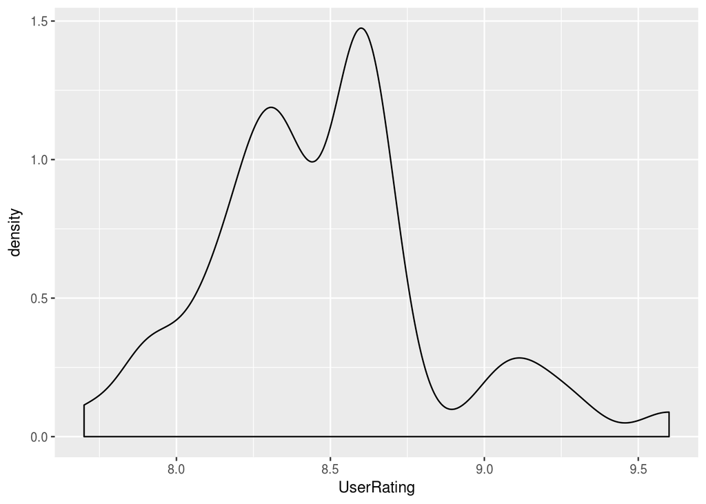

```
## # A tibble: 4 x 2
##   season correlacao_kendall
##    <int>              <dbl>
## 1      1          0.1714986
## 2      2          0.2434322
## 3      3          0.2560911
## 4      4          0.3653519
```